# Imports of used packages and settings

```python
import warnings
warnings.filterwarnings('ignore')

import pandas as pd
import numpy as np

from datetime import datetime

import collections
from collections import Counter

import operator
import umap
from itertools import cycle
from scipy import interp

import matplotlib.pyplot as plt
%matplotlib inline

from sklearn.preprocessing import StandardScaler, MinMaxScaler, RobustScaler
from sklearn.metrics import classification_report, confusion_matrix,roc_auc_score
from sklearn.metrics import accuracy_score, precision_score, recall_score, f1_score, roc_curve, auc
from sklearn.ensemble import GradientBoostingClassifier,RandomForestClassifier
from sklearn.model_selection import cross_val_score, KFold, train_test_split
from sklearn.feature_selection import chi2, SelectKBest
from sklearn.utils import class_weight, shuffle
from xgboost import XGBClassifier
from sklearn.neural_network import MLPClassifier
from sklearn.neighbors import KNeighborsClassifier
from sklearn.model_selection import KFold,StratifiedKFold
from sklearn.pipeline import make_pipeline
from sklearn.decomposition import TruncatedSVD, PCA, KernelPCA

from imblearn.over_sampling import SMOTE, RandomOverSampler
from imblearn.under_sampling import RandomUnderSampler

from xgboost import XGBClassifier


seed = 30
np.random.seed(seed)
```

# Feature engineering

```python
df = pd.read_csv("CreditTraining.csv")
print("The shape of the dataset is ", df.shape)
```

```
The shape of the dataset is  (5380, 19)
```

```python
# DATASET
df.head(10)
```

|  | Id_Customer | Y | Customer_Type | BirthDate | Customer_Open_Date | P_Client | Educational_Level | Marital_Status | Number_Of_Dependant | Years_At_Residence | Net_Annual_Income | Years_At_Business | Prod_Sub_Category | Prod_Decision_Date | Source | Type_Of_Residence | Nb_Of_Products | Prod_Closed_Date | Prod_Category |
| --- | --- | --- | --- | --- | --- | --- | --- | --- | --- | --- | --- | --- | --- | --- | --- | --- | --- | --- | --- |
| 0 | 7440 | 0 | Non Existing Client | 07/08/1977 | 13/02/2012 | NP_Client | University | Married | 3.0 | 1 | 36 | 1.0 | C | 14/02/2012 | Sales | Owned | 1 | NaN | B |
| 1 | 573 | 0 | Existing Client | 13/06/1974 | 04/02/2009 | P_Client | University | Married | 0.0 | 12 | 18 | 2.0 | C | 30/06/2011 | Sales | Parents | 1 | NaN | G |
| 2 | 9194 | 0 | Non Existing Client | 07/11/1973 | 03/04/2012 | NP_Client | University | Married | 2.0 | 10 | 36 | 1.0 | C | 04/04/2012 | Sales | Owned | 1 | NaN | B |
| 3 | 3016 | 1 | Existing Client | 08/07/1982 | 25/08/2011 | NP_Client | University | Married | 3.0 | 3 | 36 | 1.0 | C | 07/09/2011 | Sales | New rent | 1 | 31/12/2012 | L |
| 4 | 6524 | 0 | Non Existing Client | 18/08/1953 | 10/01/2012 | NP_Client | University | Married | 2.0 | 1 | 36 | 1.0 | C | 11/01/2012 | Sales | Owned | 1 | NaN | D |
| 5 | 3858 | 0 | Existing Client | 04/03/1983 | 15/09/2011 | NP_Client | University | Married | 0.0 | 28 | 60 | 2.0 | C | 04/10/2011 | Sales | Old rent | 1 | NaN | C |
| 6 | 2189 | 0 | Non Existing Client | 25/09/1979 | 17/07/2011 | NP_Client | University | Married | 0.0 | 10 | 36 | 1.0 | C | 28/07/2011 | Sales | Owned | 1 | NaN | B |
| 7 | 9338 | 0 | Non Existing Client | 04/10/1953 | 11/04/2012 | NP_Client | University | Married | 0.0 | 15 | 36 | 1.0 | C | 12/04/2012 | Sales | Owned | 1 | 16/04/2013 | B |
| 8 | 9578 | 0 | Existing Client | 01/03/1974 | 20/02/2001 | NP_Client | University | Single | 0.0 | 0 | 500 | 3.0 | P | 02/04/2012 | Branch | Owned | 1 | NaN | E |
| 9 | 173 | 1 | Existing Client | 13/02/1963 | 27/04/2011 | NP_Client | University | Married | 4.0 | 35 | 87,6 | 2.0 | C | 03/05/2011 | Sales | Owned | 1 | 18/11/2012 | L |

```python
# Y = 1
df.loc[df['Y'] == 1].head(10)
```

|  | Id_Customer | Y | Customer_Type | BirthDate | Customer_Open_Date | P_Client | Educational_Level | Marital_Status | Number_Of_Dependant | Years_At_Residence | Net_Annual_Income | Years_At_Business | Prod_Sub_Category | Prod_Decision_Date | Source | Type_Of_Residence | Nb_Of_Products | Prod_Closed_Date | Prod_Category |
| --- | --- | --- | --- | --- | --- | --- | --- | --- | --- | --- | --- | --- | --- | --- | --- | --- | --- | --- | --- |
| 3 | 3016 | 1 | Existing Client | 08/07/1982 | 25/08/2011 | NP_Client | University | Married | 3.0 | 3 | 36 | 1.0 | C | 07/09/2011 | Sales | New rent | 1 | 31/12/2012 | L |
| 9 | 173 | 1 | Existing Client | 13/02/1963 | 27/04/2011 | NP_Client | University | Married | 4.0 | 35 | 87,6 | 2.0 | C | 03/05/2011 | Sales | Owned | 1 | 18/11/2012 | L |
| 18 | 6582 | 1 | Non Existing Client | 01/07/1982 | 12/01/2012 | NP_Client | University | Married | 2.0 | 1 | 36 | 1.0 | C | 15/01/2012 | Sales | Owned | 1 | 30/09/2012 | B |
| 47 | 3853 | 1 | Existing Client | 22/06/1975 | 13/09/2011 | NP_Client | University | Married | 2.0 | 1 | 42 | 1.0 | C | 16/10/2011 | Sales | Owned | 1 | 28/06/2012 | L |
| 62 | 6724 | 1 | Non Existing Client | 07/10/1967 | 18/01/2012 | NP_Client | University | Married | 0.0 | 15 | 36 | 1.0 | C | 19/01/2012 | Sales | Owned | 1 | NaN | B |
| 66 | 1380 | 1 | Existing Client | 23/07/1977 | 04/07/2011 | NP_Client | University | Married | 0.0 | 1 | 84 | 4.0 | C | 20/07/2011 | Branch | Parents | 1 | 31/07/2012 | L |
| 89 | 7400 | 1 | Non Existing Client | 14/01/1990 | 09/02/2012 | NP_Client | University | Single | 0.0 | 1 | 25 | 1.0 | C | 12/02/2012 | Sales | Owned | 1 | 31/03/2013 | B |
| 92 | 6569 | 1 | Non Existing Client | 22/03/1972 | 09/01/2012 | NP_Client | University | Married | 4.0 | 6 | 80 | 2.0 | C | 12/01/2012 | Sales | Owned | 1 | 29/11/2012 | B |
| 97 | 3338 | 1 | Non Existing Client | 13/08/1973 | 19/09/2011 | NP_Client | University | Married | 0.0 | 10 | 50 | 10.0 | C | 22/09/2011 | Sales | Owned | 1 | 31/05/2012 | B |
| 99 | 491 | 1 | Existing Client | 03/10/1957 | 08/04/1992 | NP_Client | University | Married | 2.0 | 15 | 100 | 16.0 | C | 24/05/2011 | Branch | Owned | 1 | 29/12/2011 | C |

```python
# GENERAL FEATURES ENGINEERING FUNCTIONS

def toNumericalBinaryCategory(array,positiveLabelString):
    return [1 if x == positiveLabelString else 0 for x in array]

def get_dummies(dataframe, columnNames):
    return pd.get_dummies(dataframe, columns = columnNames)

def get_datetime(timestamps):
    return pd.to_datetime(timestamps)
```

```python
# DROP CUSTOMER ID (ALL UNIQUES)
df.drop(['Id_Customer'], axis=1, inplace=True)

# CHECK NANs
nan_values = df.isna()
nan_columns = nan_values.any()
columns_with_nan = df.columns[nan_columns].tolist()
print("Colums with NaNs: ",columns_with_nan)

a = df['Number_Of_Dependant'].isnull().sum(axis = 0)
b = df['Net_Annual_Income'].isnull().sum(axis = 0)
c = df['Years_At_Business'].isnull().sum(axis = 0)
d = df['Prod_Closed_Date'].isnull().sum(axis = 0)
rowsWithNans = pd.isna(df).any(1).nonzero()[0]

print("Number of Nans per column:")
print("Number_Of_Dependant: ",a,", Net_Annual_Income: ",b,", Years_At_Business: ",c, 'Prod_Closed_Date',d)

# REPLACE NANS WITH 0s.
df = df.fillna(0.)
```

```
Colums with NaNs:  ['Number_Of_Dependant', 'Net_Annual_Income', 'Years_At_Business', 'Prod_Closed_Date']
Number of Nans per column:
Number_Of_Dependant:  2 , Net_Annual_Income:  2 , Years_At_Business:  2 Prod_Closed_Date 4206
```

```python
# Income as string to numerical
df['Net_Annual_Income'] = [float(i.replace(',','.')) for i in df.Net_Annual_Income.astype(str)]
df['Income_for individual'] = [float(df['Net_Annual_Income'][i]) if float(df['Number_Of_Dependant'][i]) == 0.0
              else float(df['Net_Annual_Income'][i]/float(df['Number_Of_Dependant'][i])) for i in range(df.shape[0])]
```

```python
# TIME RELATED FEATURES ENGINEERING

# default time used for the datetime format.
defaultTime = pd.to_datetime(pd.DataFrame({'year': [1970],
                   'month': [1],
                   'day': [1]}))[0]

# format datetime
df['BirthDate'] =  get_datetime(df['BirthDate'])
df['Customer_Open_Date'] =  get_datetime(df['Customer_Open_Date'])
df['Prod_Decision_Date'] =  get_datetime(df['Prod_Decision_Date'])
df['Prod_Closed_Date'] = get_datetime(df['Prod_Closed_Date'])


# dates to numerical values
minClosed = df['Prod_Closed_Date'].min()
df['Closed_num'] = [int((df['Prod_Closed_Date'][i]- minClosed ).days) for i in range(df.shape[0])]

minDecision = df['Prod_Decision_Date'].min()
df['Decision_num'] = [int((df['Prod_Decision_Date'][i]- minDecision).days) for i in range(df.shape[0])]

minOpen = df['Customer_Open_Date'].min()
df['Open_num'] = [int((df['Customer_Open_Date'][i]- minOpen).days) for i in range(df.shape[0])]

minBirth = df['BirthDate'].min()
df['BirthDate_num'] = [int((df['BirthDate'][i]- minBirth).days) for i in range(df.shape[0])]


# feature engineering
df['Age_at_decision'] = [int((df['Prod_Decision_Date'][i]- df['BirthDate'][i]).days) for i in range(df.shape[0])]
df['Inbank_days_at_decision'] = [int((df['Prod_Decision_Date'][i] - df['Customer_Open_Date'][i]).days) for i in range(df.shape[0])]

df['Closed_date_exist'] = [1 if date!=defaultTime else 0 for date in df['Prod_Closed_Date']]
df['Closed_date_2013'] = [1 if int((df['Prod_Closed_Date'][i]).year)==2013 else 0 for i in range(df.shape[0])]
decision_to_close_gaps = [int((df['Prod_Closed_Date'][i] - df['Prod_Decision_Date'][i]).days) for i in range(df.shape[0])]
df['Decision_to_close_gaps'] = [gap if gap >= 0 else 0 for gap in decision_to_close_gaps]
```

```python
def get_numerical_mariage_labels(dataframe):

    numerical_mariage_labels = []

    for index, row in dataframe.iterrows():

        category = row['Marital_Status']

        if category == 'Married':
            numerical_mariage_labels.append(3)
        elif category == 'Single':
            numerical_mariage_labels.append(2)
        elif category == 'Divorced' or category =='Widowed':
            numerical_mariage_labels.append(1)
        else:
            numerical_mariage_labels.append(0)


    return numerical_mariage_labels

df['Marital'] = get_numerical_mariage_labels(df)
df.drop(columns=['Marital_Status'],inplace=True)
```

```python
# 2 STRING CLASSES TO BOOLEAN (1-0)
df['Customer_Type'] = toNumericalBinaryCategory(df['Customer_Type'],'Existing Client')
df['P_Client'] = toNumericalBinaryCategory(df['P_Client'],'NP_Client') # NO PROBLEM CLIENT =1
df['Source'] = toNumericalBinaryCategory(df['Source'],'Sales')

# DUMMITISATION FOR N-CLASSES COLUMNS
columnNames =  ['Type_Of_Residence','Prod_Category','Prod_Sub_Category','Educational_Level']
df = get_dummies(df, columnNames = columnNames)
```

```python
# TRAIN TEST SPLITTING USING STRATIFICATION ON THE CLASSES.
train, test, y_train, y_test = train_test_split(df, df['Y'], stratify = df['Y'],
                                                test_size = 0.2,random_state=seed, shuffle = True)

print("Training:",train.shape,",1 prop",y_train.sum()/y_train.shape[0])
print("Testing:",test.shape,",1 prop",y_test.sum()/y_test.shape[0])
```

```
Training: (4304, 49) ,1 prop 0.07295539033457249
Testing: (1076, 49) ,1 prop 0.07342007434944238
```

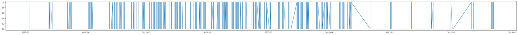

```python
# Y = 1 accross times.
trainingGroups = train.groupby(by=[train['Prod_Decision_Date'].dt.year ,train['Prod_Decision_Date'].dt.month])['Y']
sortedTrain = train.sort_values(by=['Prod_Decision_Date'])
plt.figure(figsize=(50,3))
plt.plot(sortedTrain['Prod_Decision_Date'], sortedTrain['Y'])
```

```python
# AVERAGE OF 5 MONTHS NUMBER OF Y==1
def get_prod_decision_densities(groups, dataframe):

    densities = []

    # TRAINING
    for index, row in dataframe.iterrows():

        month = row['Prod_Decision_Date'].month
        year = row['Prod_Decision_Date'].year

        unavailable = 0
        previous2MonthAvailable = True
        previousMonthAvailable = True
        nextMonthAvailable = True
        next2MonthAvailable = True

        if year == 2011:
            if month == 1:
                previousMonthAvailable = False
                previous2MonthAvailable = False
                unavailable = 2
            elif month == 2:
                previous2MonthAvailable = False
                unavailable = 1

            year = 0
        else:
            year = 1
            if month == 12:
                nextMonthAvailable = False
                next2MonthAvailable = False
                unavailable = 2
            elif month == 11:
                next2MonthAvailable = False
                unavailable = 1

        previous2Month = 0
        previousMonth = 0
        nextMonth = 0
        next2Month = 0

        if previous2MonthAvailable == True:
            previous2Month = groups[year*11 + month -3]

        if previousMonthAvailable == True:
            previousMonth = groups[year*11 + month -2]

        currentMonth = groups[year*11 + month -1]

        if nextMonthAvailable == True:
            nextMonth = groups[year*11 + month]

        if next2MonthAvailable == True:
            next2Month = groups[year *11 + month + 1]

        density = (previous2Month + previousMonth + currentMonth + nextMonth + next2Month)/(5-unavailable)
        densities.append(density)

    return densities
```

```python
# NOT USED
#train['Density'] = get_prod_decision_densities(trainingGroups.sum(), train)
#test['Density'] = get_prod_decision_densities(trainingGroups.sum(), test)
```

```python
# NUMBER OF CREDIT GIVEN/TOTAL NUMBER OF REQUESTS FOR EACH MONTH

def get_credit_ratios(ratioGroups, dataframe):

    monthly_ratios = []

    # TRAINING
    for index, row in dataframe.iterrows():

        month = row['Prod_Decision_Date'].month
        year = row['Prod_Decision_Date'].year

        if year == 2011:
            year = 0
        else:
            year = 1

        ratio = ratioGroups[year*11 + month -1]
        monthly_ratios.append(ratio)


    return monthly_ratios

ratioGroups = trainingGroups.sum()/trainingGroups.count()
ratioGroups
```

```
Prod_Decision_Date  Prod_Decision_Date
2011                1                     0.019231
                    2                     0.083333
                    3                     0.127273
                    4                     0.114943
                    5                     0.090129
                    6                     0.072727
                    7                     0.098765
                    8                     0.066225
                    9                     0.055556
                    10                    0.072829
                    11                    0.062295
                    12                    0.104247
2012                1                     0.070552
                    2                     0.080495
                    3                     0.055394
                    4                     0.056075
                    5                     0.081081
                    6                     0.047619
                    7                     0.055556
                    8                     0.022727
                    9                     0.040816
                    10                    0.096774
                    11                    0.032967
                    12                    0.103896
Name: Y, dtype: float64
```

```python
train['Monthly_ratio'] = get_credit_ratios(ratioGroups, train)
test['Monthly_ratio'] = get_credit_ratios(ratioGroups, test)
```

```python
#DROP DATETIME COLUMNS
train.drop(columns=['BirthDate','Customer_Open_Date','Prod_Decision_Date','Prod_Closed_Date'],inplace=True)
test.drop(columns=['BirthDate','Customer_Open_Date','Prod_Decision_Date','Prod_Closed_Date'],inplace=True)
```

# Datasets definition

```python
# X_train, y_train, X_test, y_test

y_train = train['Y']
X_train = train.drop('Y', axis =1)

y_test = test['Y']
X_test = test.drop('Y', axis =1)

columnNames= X_train.columns
```

# Feature importance

```python
featureSelectionScaler= MinMaxScaler()

select_X_train = featureSelectionScaler.fit_transform(X_train)

# Select n features with highest chi-squared statistics
chi2_selector = SelectKBest(chi2, k=10)
chi2_selector.fit(select_X_train, y_train)

chi2_scores = pd.DataFrame(list(zip(columnNames, chi2_selector.scores_, chi2_selector.pvalues_)), columns=['ftr', 'score', 'pval'])
print(chi2_scores)

kbest = np.asarray(columnNames)[chi2_selector.get_support()]
print("Columns to retain")
print(kbest)
```

```
                                    ftr       score           pval
0                         Customer_Type    0.244166   6.212131e-01
1                              P_Client    0.306432   5.798780e-01
2                   Number_Of_Dependant    0.162676   6.867046e-01
3                    Years_At_Residence    0.415279   5.193021e-01
4                     Net_Annual_Income    0.321189   5.708941e-01
5                     Years_At_Business    0.319841   5.717030e-01
6                                Source    0.302139   5.825444e-01
7                        Nb_Of_Products    5.440756   1.967215e-02
8                 Income_for individual    0.333472   5.636219e-01
9                            Closed_num  705.895784  1.561834e-155
10                         Decision_num    0.269053   6.039675e-01
11                             Open_num    0.210960   6.460163e-01
12                        BirthDate_num    1.678905   1.950700e-01
13                      Age_at_decision    2.771228   9.597252e-02
```

[output cut: 35 more lines]

```python
# For Cross validation

X_Cross = X_train[kbest].to_numpy()
y_Cross = y_train.to_numpy()

X_test = X_test[kbest]
y_test = y_test.to_numpy()
```

# Saving the Training set for Hyperparameter search and Auto-Sklearn

```python
dsave = {
    "X": X_Cross,
    "y": y_Cross,
}
with open("credits.npz", 'wb') as fp:
    np.savez(fp, **dsave)
```

```python
# THE PARTICULARITY OF THIS DATASET IS THAT IT IS HIGLY IMBALANCED. SECONDLY, FALSE POSITIVES ARE REALLY IMPORTANT
# AND HAVE TO MINIMISED AS MUCH AS POSSIBLE WHEN DEALING WITH CREDIT REQUESTS.
# THIS IS WHY, ACCURACY IS NOT A GOOD METRIC IN THIS CASE AND OTHER METRICS MUST BE USED.

#high recall + high precision : the class is perfectly handled by the model
#low recall + high precision : the model can’t detect the class well but is highly trustable when it does
#high recall + low precision : the class is well detected but the model also include points of other classes in it
#low recall + low precision : the class is poorly handled by the model

# IN ORDER TO HAVE A REALITIVELY USEFUL AND EASY METRICS TO WATCH, WE USED THE F1-SCORE WHICH IS A BALANCE BETWEEN THE
# RECALL AND PRECISION SCORES.


# SHOW THE ROC CURVE A PREDICTION USING THE PROBABILITIES AND THRESHOLD.
# IT ALSO GIVES THE BEST THRESHOLD TO USE FOR A MAXIMAL F1-SCORE.

def show_model_score(true_pred, pred_probabilities):

    target_names = ["0"]

    thresholds = np.arange(0.0,1.0, 0.01)

    bestF1 = 0.0
    bestF1Threshold = 0.0

    for threshold in thresholds:


        pred = [0 if proba <= threshold else 1 for proba in pred_probabilities]
        report = classification_report(true_pred,pred, output_dict =True)
        f1_score = report['1']['f1-score']
        if f1_score > bestF1:
            bestF1 = f1_score
            bestF1Threshold  = threshold


    print("Results for best threshold of:", bestF1Threshold)
    pred = [0 if proba <= bestF1Threshold else 1 for proba in pred_probabilities]
    print(classification_report(true_pred,pred))

    print("\nROC")
    baseline = [0 for _ in range(len(true_pred))]
    # calculate scores
    ns_auc = roc_auc_score(true_pred, baseline)
    lr_auc = roc_auc_score(true_pred, pred_probabilities)
    # summarize scores
    print('No Skill: ROC AUC=%.3f' % (ns_auc))
    print('NN: ROC AUC=%.3f' % (lr_auc))
    # calculate roc curves
    ns_fpr, ns_tpr, _ = roc_curve(true_pred, baseline)
    lr_fpr, lr_tpr, _ = roc_curve(true_pred, pred_probabilities)
    # plot the roc curve for the model
    plt.plot(ns_fpr, ns_tpr, linestyle='--', label='No Skill')
    plt.plot(lr_fpr, lr_tpr, marker='.', label='NN')
    # axis labels
    plt.xlabel('False Positive Rate')
    plt.ylabel('True Positive Rate')
    # show the legend
    plt.legend()
    # show the plot
    plt.show()


# ONLY FIND BEST F1-SCORE AND ITS THRESHOLD
def get_best_f1_threshold(true_pred, pred_probabilities):

    target_names = ["0"]

    thresholds = np.arange(0.0,1.0, 0.01)

    bestF1 = 0.0
    bestF1Threshold = 0.0

    for threshold in thresholds:

        pred = [0 if proba <= threshold else 1 for proba in pred_probabilities]
        report = classification_report(true_pred,pred, output_dict =True)
        f1_score = report['1']['f1-score']
        if f1_score > bestF1:
            bestF1 = f1_score
            bestF1Threshold  = threshold


    return (bestF1,bestF1Threshold)
```

# Model fitting & Model selection

```
f1 score (Valid):  0.7142857142857143 , prop = 0.07424593967517401
f1 score (Valid) with threshold:  0.7666666666666666 ,validation threshold: 0.64

f1 score (Valid):  0.7142857142857143 , prop = 0.07424593967517401
f1 score (Valid) with threshold:  0.7999999999999999 ,validation threshold: 0.79

f1 score (Valid):  0.6666666666666666 , prop = 0.07424593967517401
f1 score (Valid) with threshold:  0.7096774193548386 ,validation threshold: 0.7000000000000001

f1 score (Valid):  0.6486486486486486 , prop = 0.07424593967517401
f1 score (Valid) with threshold:  0.6885245901639345 ,validation threshold: 0.77

f1 score (Valid):  0.7428571428571428 , prop = 0.07209302325581396
f1 score (Valid) with threshold:  0.7999999999999999 ,validation threshold: 0.75

f1 score (Valid):  0.7301587301587302 , prop = 0.07209302325581396
f1 score (Valid) with threshold:  0.7407407407407407 ,validation threshold: 0.8

f1 score (Valid):  0.626865671641791 , prop = 0.07209302325581396
f1 score (Valid) with threshold:  0.6666666666666667 ,validation threshold: 0.76

f1 score (Valid):  0.6885245901639343 , prop = 0.07209302325581396
f1 score (Valid) with threshold:  0.6885245901639343 ,validation threshold: 0.49

f1 score (Valid):  0.6133333333333333 , prop = 0.07209302325581396
f1 score (Valid) with threshold:  0.7017543859649122 ,validation threshold: 0.72

f1 score (Valid):  0.64 , prop = 0.07209302325581396
f1 score (Valid) with threshold:  0.6666666666666667 ,validation threshold: 0.84

f1 score (Test):  0.7398843930635838 , prop = 0.07342007434944238
f1 score (Test) with threshold:  0.7887323943661971 ,validation threshold: 0.79
Confusion matrix
[[990   7]
 [ 23  56]]
Results obtained with validation model:
Results for best threshold of: 0.79
              precision    recall  f1-score   support

           0       0.98      0.99      0.99       399
           1       0.86      0.75      0.80        32

    accuracy                           0.97       431
   macro avg       0.92      0.87      0.89       431
weighted avg       0.97      0.97      0.97       431


ROC
No Skill: ROC AUC=0.500
NN: ROC AUC=0.917
```

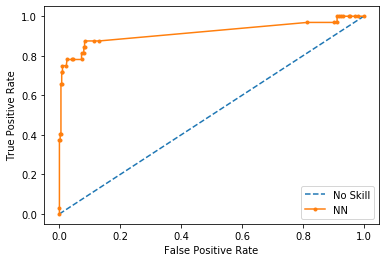

```
None
```

```python
# STRATIFIED K-FOLD FOR CROSS VALIDATION.
stratKF = StratifiedKFold(n_splits = 10, random_state=seed)

best_model = None
best_scaler = None
best_score = 0
best_model_y_valid_true = None
best_model_y_valid_proba = None

for train_index, valid_index in stratKF.split(X_Cross,y_Cross):

    # train - valid
    X_train, X_valid = X_Cross[train_index], X_Cross[valid_index]
    y_train, y_valid = y_Cross[train_index], y_Cross[valid_index]

    # over sampling of the minority class to be equal to 40 % of the majority class.
    over = RandomOverSampler(sampling_strategy=0.4, random_state =seed)
    X_train, y_train = over.fit_resample(X_train, y_train)

    # scaling
    scaler = MinMaxScaler()
    X_train = scaler.fit_transform(X_train)
    X_valid = scaler.transform(X_valid)

    # model
    model = GradientBoostingClassifier(n_estimators=220, random_state=seed)
    model.fit(X_train, y_train)

    # predictions
    y_pred = model.predict(X_valid)
    y_pred_proba = model.predict_proba(X_valid)[:,1]

    # best f1 and threshold
    (valid_f1,valid_threshold) = get_best_f1_threshold(y_valid,y_pred_proba)

    score = f1_score(y_valid, y_pred)
    print("f1 score (Valid): ", score, f", prop = {y_valid.sum()/y_valid.shape[0]}")
    print("f1 score (Valid) with threshold: ", valid_f1, ",validation threshold:", valid_threshold)

    if valid_f1 > best_score:

        best_model = model
        best_scaler = scaler
        best_score = valid_f1
        best_thres = valid_threshold
        best_model_y_valid_true = y_valid
        best_model_y_valid_proba = y_pred_proba


    print("")

# use best validation model and predict on the test set using a threshold of 0.5
# and the validation model best threshold.
# it can be shown that in general, it increases drastically the model scores with unbalanced classes.

y_pred = best_model.predict(best_scaler.transform(X_test))
score = f1_score(y_test, y_pred)
print("f1 score (Test): ", score, f", prop = {y_test.sum()/y_test.shape[0]}")

y_pred_proba = best_model.predict_proba(best_scaler.transform(X_test))[:,1]
y_pred = [0 if proba <= best_thres else 1 for proba in y_pred_proba]
score = f1_score(y_test, y_pred)
print("f1 score (Test) with threshold: ", score, ",validation threshold:", best_thres)
print("Confusion matrix")
print(confusion_matrix(y_test,y_pred))
print('Results obtained with validation model:')
print(show_model_score(best_model_y_valid_true,best_model_y_valid_proba))
```

Looking at the results above, the validation model retained obtained a 0.8 f1-score for the 0.79 threshold Applying this model on the test set, we obtained 0.739 f1-score. Applying this model on the test set with the threshold, we obtained 0.788 f1-score.

```python
# model

over = RandomOverSampler(sampling_strategy=0.4, random_state =seed)
X_train, y_train = over.fit_resample(X_Cross, y_Cross)

# scaling
scaler = MinMaxScaler()
X_train = scaler.fit_transform(X_train)

print("RESULTS FOR GRADIENT BOOSTING ON THE TEST SET USING THE WHOLE TRAINING SET:")

model = GradientBoostingClassifier(n_estimators = 220, random_state= seed)
model.fit(X_train, y_train)

# predictions
y_pred = model.predict(scaler.transform(X_test))
score = f1_score(y_test, y_pred)
print("F1-score(Test) without threshold is:",score)

y_pred_proba = model.predict_proba(scaler.transform(X_test))[:,1]
y_pred = [0 if proba <= best_thres else 1 for proba in y_pred_proba]
score = f1_score(y_test, y_pred)
print("f1 score (Test) with threshold: ", score, ",validation threshold:", best_thres)
```

```
RESULTS FOR GRADIENT BOOSTING ON THE TEST SET USING THE WHOLE TRAINING SET:
F1-score(Test) without threshold is: 0.7251461988304092
f1 score (Test) with threshold:  0.75 ,validation threshold: 0.79
```

# Clustering and Data Vizualisation

In this part we try different way of compressing the data and then vizualising them to understand if clusters exist and why are the data so hard to seperate.

```python
# X_train, y_train, X_test, y_test on the full training dataset ( all feature engineered)

y_train = train['Y']
X_train = train.drop('Y', axis =1)

y_test = test['Y']
X_test = test.drop('Y', axis =1)

columnNames = X_train.columns
```

```python
print(np.shape(X_train))
print(np.shape(y_train))
```

```
(4304, 45)
(4304,)
```

```python
def plot_scatter(X,  color, alpha=0.5, ax=None):
    if ax is None:
        return plt.scatter(X[:, 0],
                       X[:, 1],
                       c=color,
                       alpha=alpha,
                       edgecolor='k')
    else:
        return ax.scatter(X[:, 0],
                       X[:, 1],
                       c=color,
                       alpha=alpha,
                       edgecolor='k')
```

```
Explained variance ratio:  [0.01964688 0.54936922]
Singular values:  [1454840.33612105  425383.72616121]
(4304, 2)
```

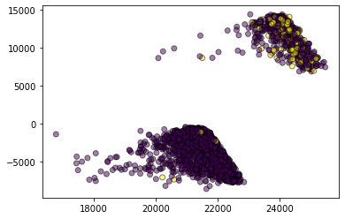

```python
# DIMENSIONALITY REDUCTION

svd = TruncatedSVD(n_components=2, n_iter=20, random_state=seed)
svd.fit(X_train)

print("Explained variance ratio: ", svd.explained_variance_ratio_)
print("Singular values: ", svd.singular_values_)

red_X_train = svd.transform(X_train)
print(np.shape(red_X_train))

plot_scatter(red_X_train, y_train)
plt.show()
```

```
(4304, 2)
```

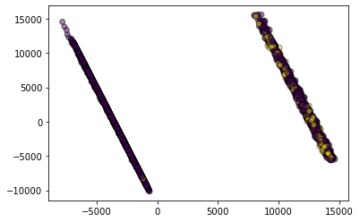

```python
pca = PCA(n_components=2, random_state=seed)
pca.fit(X_train)
red_X_train = pca.transform(X_train)
print(np.shape(red_X_train))
plot_scatter(red_X_train, y_train)
plt.show()
```

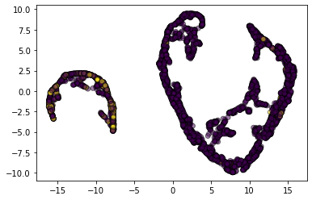

```python
umap_transformer = umap.UMAP(n_components=2)
red_X_train = umap_transformer.fit_transform(X_train)
plot_scatter(red_X_train, y_train)
plt.show()
```

```
Metric=euclidean, nn=2
Metric=euclidean, nn=5
Metric=euclidean, nn=10
```

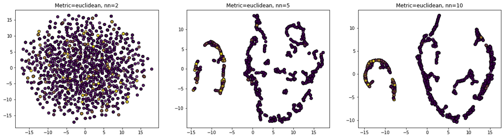

```
Metric=canberra, nn=2
Metric=canberra, nn=5
Metric=canberra, nn=10
```

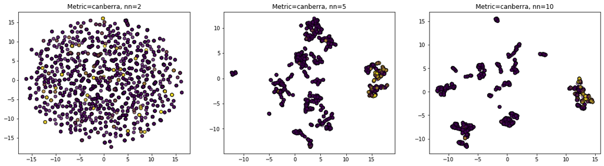

```
Metric=cosine, nn=2
Metric=cosine, nn=5
Metric=cosine, nn=10
```

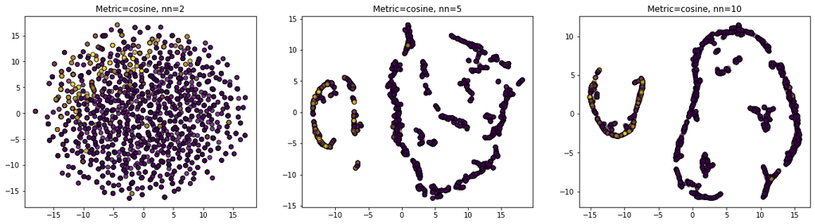

```
Metric=hamming, nn=2
Metric=hamming, nn=5
Metric=hamming, nn=10
```

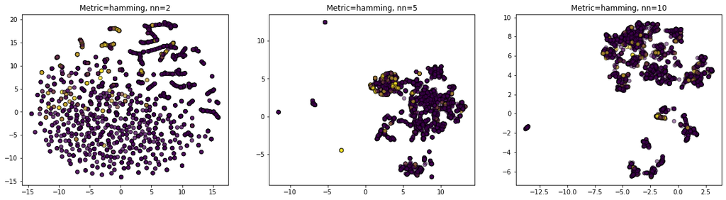

```
Metric=jaccard, nn=2
Metric=jaccard, nn=5
Metric=jaccard, nn=10
```

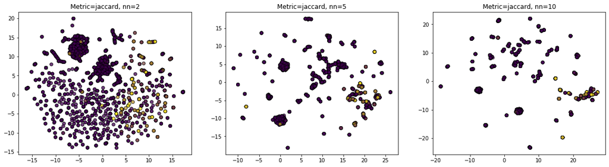

```python
metrics = ["euclidean", "canberra", "cosine", "hamming", "jaccard"]
nns = [2, 5, 10]

for metric in metrics:
    fig = plt.figure(figsize=(20, 5))
    for i, nn in enumerate(nns):
        print(f"Metric={metric}, nn={nn}")
        try:
            umap_transformer = umap.UMAP(metric=metric, n_neighbors=nn, min_dist=0.0)
            red_X_train = umap_transformer.fit_transform(X_train)
            plt.subplot(1,len(nns),i+1).set_title(f"Metric={metric}, nn={nn}")
            plot_scatter(red_X_train, y_train)
        except ValueError:
            print("value error...")
    plt.show()
```

AS SHOWN ABOVE, THE TWO CLASSES ARE NOT PERFLECTLY SEPARABLE, THE Y CLASS SEEMS TO BE STACKED ON TOP OF ANOTHER PART OF THE 0 CLASS. THIS SUPERPOSITION MAKES THE CLASSIFICATION REALLY DIFFICULT ON TOP OF BEING AN UNBALANCED DATASET.

# AutoML with DeepHyper

DEEPHYPER is A Scalable Asynchronous Neural Architecture and Hyperparameter Search for Deep Neural Networks. It allows for architectures and hyperparameter search using optimization strategies such as AMBS for instance. This library is currently being modified, develop and run by the deephyper team which include Romain EGELE, one of the author of this report. Because this research needs a lot of dependancies and is not currently added on the github, a simplified but not executable version of it has been added to this report.

```
"""
file: problem.py
"""

import ConfigSpace as cs
import ConfigSpace.hyperparameters as csh
from deephyper.problem import HpProblem


Problem = HpProblem(seed=45)

classifier = Problem.add_hyperparameter(
    name="classifier",
    value=["RandomForest", "Logistic", "AdaBoost", "KNeighbors", "MLP", "SVC", "XGBoost", "GradientBoosting"],
)

# n_estimators
n_estimators = Problem.add_hyperparameter(
    name="n_estimators", value=(1, 2000, "log-uniform")
)

cond_n_estimators = cs.OrConjunction(
    cs.EqualsCondition(n_estimators, classifier, "RandomForest"),
    cs.EqualsCondition(n_estimators, classifier, "AdaBoost"),
    cs.EqualsCondition(n_estimators, classifier, "GradientBoosting"),
)

Problem.add_condition(cond_n_estimators)

# max_depth
max_depth = Problem.add_hyperparameter(name="max_depth", value=(2, 100, "log-uniform"))

cond_max_depth = cs.OrConjunction(
    cs.EqualsCondition(max_depth, classifier, "RandomForest"),
    cs.EqualsCondition(max_depth, classifier, "XGBoost")
)

Problem.add_condition(cond_max_depth)

# n_neighbors
n_neighbors = Problem.add_hyperparameter(name="n_neighbors", value=(1, 100))

cond_n_neighbors = cs.EqualsCondition(n_neighbors, classifier, "KNeighbors")

Problem.add_condition(cond_n_neighbors)

# alpha
alpha = Problem.add_hyperparameter(name="alpha", value=(1e-5, 10.0, "log-uniform"))

cond_alpha = cs.EqualsCondition(alpha, classifier, "MLP")

Problem.add_condition(cond_alpha)

# C
C = Problem.add_hyperparameter(name="C", value=(1e-5, 10.0, "log-uniform"))

cond_C = cs.OrConjunction(
    cs.EqualsCondition(C, classifier, "Logistic"),
    cs.EqualsCondition(C, classifier, "SVC"),
)

Problem.add_condition(cond_C)

# kernel
kernel = Problem.add_hyperparameter(
    name="kernel", value=["linear", "poly", "rbf", "sigmoid"]
)

cond_kernel = cs.EqualsCondition(kernel, classifier, "SVC")

Problem.add_condition(cond_kernel)

# gamma
gamma = Problem.add_hyperparameter(name="gamma", value=(1e-5, 10.0, "log-uniform"))

cond_gamma = cs.OrConjunction(
    cs.EqualsCondition(gamma, kernel, "rbf"),
    cs.EqualsCondition(gamma, kernel, "poly"),
    cs.EqualsCondition(gamma, kernel, "sigmoid"),
    cs.EqualsCondition(gamma, classifier, "XGBoost")
)

Problem.add_condition(cond_gamma)

if __name__ == "__main__":
    print(Problem)
```

```
"""
file: load_data.py
"""
import numpy as np

import os
HERE = os.path.dirname(os.path.abspath(__file__)) # useful to locate data files with respect to this file

np.random.seed(2018)

def load_data():
    """

    Return:
        Tuple of Numpy arrays: ``(train_X, train_y), (valid_X, valid_y)``.
    """
    fname = "credits.npz"
    data_path = os.path.join(HERE, fname)
    with open(data_path, 'rb') as fp:
        data = {k: arr for k,arr in np.load(fp, allow_pickle=True).items()}

    X = data["X"]
    y = data["y"]

    print(f'X: {np.shape(X)}, y: {np.shape(y)}')

    # Interface to run training data must me respected
    return X, y

if __name__ == '__main__':
    load_data()
```

```
"""
file: run.py
"""
import inspect
from inspect import signature
from pprint import pprint

import numpy as np
from imblearn.over_sampling import SMOTE, RandomOverSampler
from sklearn.discriminant_analysis import QuadraticDiscriminantAnalysis
from sklearn.ensemble import (AdaBoostClassifier, GradientBoostingClassifier,
                              RandomForestClassifier)
from sklearn.linear_model import LogisticRegression
from sklearn.metrics import accuracy_score, classification_report, f1_score
from sklearn.model_selection import (KFold, StratifiedKFold, cross_val_score,
                                     train_test_split)
from sklearn.neighbors import KNeighborsClassifier
from sklearn.neural_network import MLPClassifier
from sklearn.pipeline import make_pipeline
from sklearn.preprocessing import MinMaxScaler, StandardScaler
from sklearn.svm import SVC
from xgboost import XGBClassifier

from creditnas.autosklearn1.load_data import load_data
from deephyper.search.nas.model.preprocessing import minmaxstdscaler

SEED = 30
np.random.seed(SEED)

def get_best_f1_threshold(true_pred, pred_probabilities):

    target_names = ["0"]

    thresholds = np.arange(0.0,1.0, 0.01)

    bestF1 = 0.0
    bestF1Threshold = 0.0

    for threshold in thresholds:

        pred = [0 if proba <= threshold else 1 for proba in pred_probabilities]
        report = classification_report(true_pred,pred, output_dict =True)
        f1_score = report['1']['f1-score']
        if f1_score > bestF1:
            bestF1 = f1_score
            bestF1Threshold  = threshold


    return bestF1, bestF1Threshold

def run(config: dict) -> float:
    """Run function which can be used for AutoML classification.

    Args:
        config (dict): [description]
        load_data (callable): [description]

    Returns:
        float: [description]
    """
    seed = SEED
    config["random_state"] = seed

    smote_k_neighbors = 3 #config["smote_k_neighbors"]

    X, y = load_data()

    mapping = {
        "RandomForest": RandomForestClassifier,
        "Logistic": LogisticRegression,
        "AdaBoost": AdaBoostClassifier,
        "KNeighbors": KNeighborsClassifier,
        "MLP": MLPClassifier,
        "SVC": SVC,
        "XGBoost": XGBClassifier,
        "GradientBoosting": GradientBoostingClassifier
    }

    clf_class = mapping[config["classifier"]]

    # keep parameters possible for the current classifier
    sig = signature(clf_class)
    clf_allowed_params = list(sig.parameters.keys())
    clf_params = {
        k: v
        for k, v in config.items()
        if k in clf_allowed_params and not (v in ["nan", "NA"])
    }

    if "n_jobs" in clf_allowed_params:  # performance parameter
        clf_params["n_jobs"] = 4

    try:  # good practice to manage the fail value yourself...


        # cross_score = cross_val_score(pipeline, X, y, cv=5, scoring='f1', n_jobs=4)
        # kf = KFold(n_splits=10, random_state=42, shuffle=True)
        kf = StratifiedKFold(n_splits = 10, random_state=seed)
        cross_score = []

        for train_index, valid_index in kf.split(X, y):
            X_train, X_valid = X[train_index], X[valid_index]
            y_train, y_valid = y[train_index], y[valid_index]

            over = RandomOverSampler(sampling_strategy=0.4, random_state =seed)
            X_train, y_train = over.fit_resample(X_train, y_train)

            scaler = MinMaxScaler()
            # scaler = minmaxstdscaler()
            X_train = scaler.fit_transform(X_train)
            X_valid = scaler.transform(X_valid)

            clf = clf_class(**clf_params)

            clf.fit(X_train, y_train)


            try:
                y_pred_proba = clf.predict_proba(X_valid)[:,1]
                (valid_f1,valid_threshold) = get_best_f1_threshold(y_valid,y_pred_proba)
                score = valid_f1
            except:
                y_pred = clf.predict(X_valid)
                score = f1_score(y_valid, y_pred)

            cross_score.append(score)

        fit_is_complete = True
    except:
        fit_is_complete = False

    if fit_is_complete:
        score = max(cross_score)
    else:
        score = -1.0

    return score
```

Command to run with DeepHyper using previous files:

```
$ python -m deephyper.search.hps.ambs --problem creditnas.autosklearn1.problem.Problem --run creditnas.autosklearn1.run.run --evaluator subprocess
```

## F1 Score on validation set with respect to time

[figure not shown]

## Stack plot of F1 score per evaluation colored by f1 scored

[figure not shown]

## Stack plot of F1 score per evaluation colored by f1 scored removing worse classifiers for better coloring

[figure not shown]

AS SHOWN ABOVE, XGBOOST SEEMS TO PERFORM THE BEST ON THE VALIDATION SET WITH SCORES SCORING AS HIGH AS 0.8. THE RESULT OF THIS SEARCH HAS BEEN ADDED TO THIS REPORT WITHIN THE RESULTS.CSV FILES.

FURTHERMORE, IT CAN BE SEEN THAT THERE IS A LOT OF DISCREPENCIES BETWEEN THE MODELS RESULTS EVEN BETWEEN VALIDATION MODELS. indeed the data being not so easily separable, it appears that some y=1 class yield more predictive power than some others y=1. The splitting hence induce randomness and different mixes of important/non important y=1 which can drastically changes the models results.

```python
X_Cross = X_Cross
y_Cross = y_Cross

X_test = X_test[kbest]
y_test = y_test.to_numpy()
```

```
f1 score (Valid):  0.6944444444444444 , prop = 0.07424593967517401
f1 score (Valid) with threshold:  0.7924528301886793 ,validation threshold: 0.8300000000000001

f1 score (Valid):  0.6399999999999999 , prop = 0.07424593967517401
f1 score (Valid) with threshold:  0.7796610169491525 ,validation threshold: 0.81

f1 score (Valid):  0.625 , prop = 0.07424593967517401
f1 score (Valid) with threshold:  0.7272727272727272 ,validation threshold: 0.7000000000000001

f1 score (Valid):  0.5952380952380952 , prop = 0.07424593967517401
f1 score (Valid) with threshold:  0.676923076923077 ,validation threshold: 0.71

f1 score (Valid):  0.7222222222222222 , prop = 0.07209302325581396
f1 score (Valid) with threshold:  0.8070175438596492 ,validation threshold: 0.8

f1 score (Valid):  0.6666666666666666 , prop = 0.07209302325581396
f1 score (Valid) with threshold:  0.7241379310344828 ,validation threshold: 0.65

f1 score (Valid):  0.5714285714285714 , prop = 0.07209302325581396
f1 score (Valid) with threshold:  0.6181818181818182 ,validation threshold: 0.8

f1 score (Valid):  0.6857142857142857 , prop = 0.07209302325581396
f1 score (Valid) with threshold:  0.7058823529411764 ,validation threshold: 0.5700000000000001

f1 score (Valid):  0.6153846153846153 , prop = 0.07209302325581396
f1 score (Valid) with threshold:  0.6875 ,validation threshold: 0.72

f1 score (Valid):  0.627906976744186 , prop = 0.07209302325581396
f1 score (Valid) with threshold:  0.7213114754098361 ,validation threshold: 0.81

f1 score (Test):  0.7415730337078652 , prop = 0.07342007434944238
f1 score (Test) with threshold:  0.7412587412587414 ,validation threshold: 0.8
Confusion matrix
[[986  11]
 [ 26  53]]
Results obtained with validation model:
Results for best threshold of: 0.8
              precision    recall  f1-score   support

           0       0.98      0.99      0.99       399
           1       0.88      0.74      0.81        31

    accuracy                           0.97       430
   macro avg       0.93      0.87      0.90       430
weighted avg       0.97      0.97      0.97       430


ROC
No Skill: ROC AUC=0.500
NN: ROC AUC=0.924
```

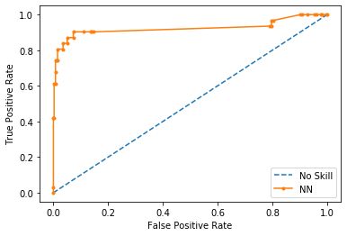

```
None
```

```python
# EXPERIMENTATAL RESULTS FOR A xgboost MODEL FOUND USING DEEPHYPER
# max_depth =2 , gamma = 0.00011985661384340067

# STRATIFIED K-FOLD FOR CROSS VALIDATION.
stratKF = StratifiedKFold(n_splits = 10, random_state=seed)

best_model = None
best_scaler = None
best_score = 0
best_model_y_valid_true = None
best_model_y_valid_proba = None

for train_index, valid_index in stratKF.split(X_Cross,y_Cross):

    # train - valid
    X_train, X_valid = X_Cross[train_index], X_Cross[valid_index]
    y_train, y_valid = y_Cross[train_index], y_Cross[valid_index]

    # over sampling of the minority class to be equal to 40 % of the majority class.
    over = RandomOverSampler(sampling_strategy=0.4, random_state =seed)
    X_train, y_train = over.fit_resample(X_train, y_train)

    # scaling
    scaler = MinMaxScaler()
    X_train = scaler.fit_transform(X_train)
    X_valid = scaler.transform(X_valid)

    # model
    model = XGBClassifier(max_depth=2, gamma =0.00011985661384340067)
    model.fit(X_train, y_train)

    # predictions
    y_pred = model.predict(X_valid)
    y_pred_proba = model.predict_proba(X_valid)[:,1]

    # best f1 and threshold
    (valid_f1,valid_threshold) = get_best_f1_threshold(y_valid,y_pred_proba)

    score = f1_score(y_valid, y_pred)
    print("f1 score (Valid): ", score, f", prop = {y_valid.sum()/y_valid.shape[0]}")
    print("f1 score (Valid) with threshold: ", valid_f1, ",validation threshold:", valid_threshold)

    if valid_f1 > best_score:

        best_model = model
        best_scaler = scaler
        best_score = valid_f1
        best_thres = valid_threshold
        best_model_y_valid_true = y_valid
        best_model_y_valid_proba = y_pred_proba


    print("")

# use best validation model and predict on the test set using a threshold of 0.5
# and the validation model best threshold.
# it can be shown that in general, it increases drastically the model scores with unbalanced classes.

y_pred = best_model.predict(best_scaler.transform(X_test))
score = f1_score(y_test, y_pred)
print("f1 score (Test): ", score, f", prop = {y_test.sum()/y_test.shape[0]}")

y_pred_proba = best_model.predict_proba(best_scaler.transform(X_test))[:,1]
y_pred = [0 if proba <= best_thres else 1 for proba in y_pred_proba]
score = f1_score(y_test, y_pred)
print("f1 score (Test) with threshold: ", score, ",validation threshold:", best_thres)
print("Confusion matrix")
print(confusion_matrix(y_test,y_pred))
print('Results obtained with validation model:')
print(show_model_score(best_model_y_valid_true,best_model_y_valid_proba))
```

```python
over = RandomOverSampler(sampling_strategy=0.4, random_state =seed)
X_train, y_train = over.fit_resample(X_Cross, y_Cross)

# scaling
scaler = MinMaxScaler()
X_train = scaler.fit_transform(X_train)

print("RESULTS FOR XGBOOST OF DEEPHYPER ON THE TEST SET USING THE WHOLE TRAINING SET:")

# model
model = XGBClassifier(max_depth=2, gamma =0.00011985661384340067)
model.fit(X_train, y_train)

# predictions
y_pred = model.predict(scaler.transform(X_test))
score = f1_score(y_test, y_pred)
print("F1-score(Test) without threshold is:",score)

y_pred_proba = model.predict_proba(scaler.transform(X_test))[:,1]
y_pred = [0 if proba <= best_thres else 1 for proba in y_pred_proba]
score = f1_score(y_test, y_pred)
print("f1 score (Test) with threshold: ", score, ",validation threshold:", best_thres)
```

```
RESULTS FOR XGBOOST OF DEEPHYPER ON THE TEST SET USING THE WHOLE TRAINING SET:
F1-score(Test) without threshold is: 0.7374301675977653
f1 score (Test) with threshold:  0.7714285714285715 ,validation threshold: 0.8
```

USING THE WHOLE DATASET, THE XGBOOST CLASSIFIER WITH DEEPHYPER HYPERPARAMETERS ACHIEVE A 0.77 ON THE TEST SET. (using the found validation threshold)